# Investigating the exponential distribution in R and comparing it with the Central Limit Theorem

Vinicios Pereira

05/07/2018

## Overview

In this report, we will investigate the exponential distribution in R and compare it with the Central Limit Theorem. The exponential distribution can be simulated in R with rexp(n, lambda) where lambda is the rate parameter. The mean of the exponential distribution is 1/*lambda* and the standard deviation is also 1/*lambda*.

## Simulations

According to [Wikipedia](https://en.wikipedia.org/wiki/Exponential_distribution), the exponential distribution (also known as negative exponential distribution) is the probability distribution that describes the time between events in a Poisson point process, i.e., a process in which events occur continuously and independently at a constant average rate. It is a particular case of the gamma distribution.

The mean or expected value of an exponentially distributed random variable X with rate parameter *lambda* is given by: **E[X] = 1/*lambda***. The variance of X is given by **Var[X] = 1/*lambda*^2** and the standart deviation is equal to the mean, *sigma* = 1/*lambda*.

For simulation propose, we will set *lambda* = 0.2 for all cases. We will investigate the distribution of averages of **40** exponentials variables through **1000** simulations.

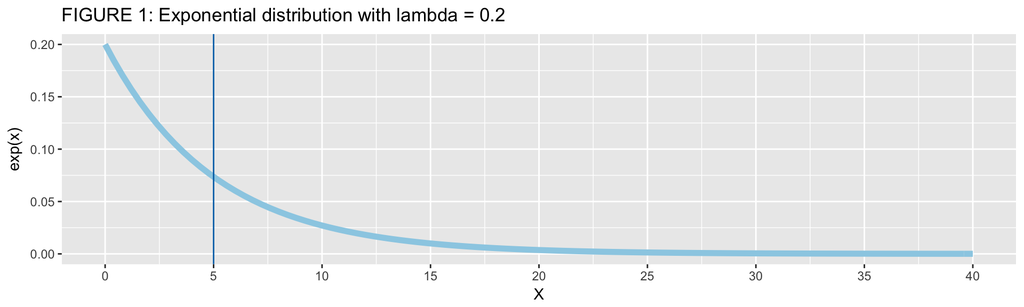

```r
lambda = 0.2
ggplot(data.frame(x=c(0,40)),aes(x=x)) +
     stat_function(fun=dexp, geom = "line", size = 2, col = "#9bcfe5", args = (mean=0.2)) +
     scale_size_area(max_size = 30) +
     ggtitle("FIGURE 1: Exponential distribution with lambda = 0.2") +
     xlab("X") +
     ylab("exp(x)") +
     geom_vline(xintercept = 1/lambda, col = "#0075b7") +
     scale_x_continuous(breaks = c(0 ,1/lambda, 2/lambda, 3/lambda, 4/lambda, 5/lambda, 6/lambda, 7/lambda,
                                   8/lambda))
```

FIGURE 1 shows the Exponencial distribution with *lambda* = 0.2. The vertical line represents the Theoretical Mean *mu* = E[X] = 1/*lambda* = 5. The values shown in the X axis represents the Teoretical Standart Deviation gaps, *sigma* = 1/*lambda* = 5. It means the Theoretical Variance is **Var[X] = 1/*lambda*^2 = 25**.

```r
mu = 1/lambda
sigma = 1/lambda
var = 1/lambda^2
```

To illustrate via simulation and associated explanatory text the properties of the distribution of the mean of 40 exponentials, we will:

1. Show the sample mean and compare it to the theoretical mean of the distribution.
2. Show how variable the sample is (via variance) and compare it to the theoretical variance of the distribution.
3. Show that the distribution is approximately normal.

Let’s simulate n exp(X) 1000 times. We will simulate with n = 10, 25 and 40 to see how the distribution of the distribution of the averages, properly normalized, approach to a standard normal as the sample increases.

```r
# Number of simulations.
nosim <- 1000

# Set the seed to assure reproducibility.
set.seed(885)
# Create matrix 1000 X 10 with random values from exponential distribution lambda.
mSimulation10 <- matrix(rexp(nosim * 10, lambda), nosim)
# Create matrix 1000 X 25 with random values from exponential distribution lambda.
mSimulation25 <- matrix(rexp(nosim * 25, lambda), nosim)
# Create matrix 1000 X 40 with random values from exponential distribution lambda.
mSimulation40 <- matrix(rexp(nosim * 40, lambda), nosim)

# Function to standardize the simulations means.
standMeanfunc <- function(x, n) (mean(x) - mu) / (sigma / sqrt(n))

# Create a data frame with the standardized means for each simulation matrix.
dfStandMeans <- data.frame(x = c(apply(mSimulation10, 1, standMeanfunc, 10),
                        apply(mSimulation25, 1, standMeanfunc, 25),
                        apply(mSimulation40, 1, standMeanfunc, 40)),
                  size = factor(rep(c(10, 25, 40), rep(nosim, 3))))

# Create a data frame with the standardized means for each simulation matrix.
dfVariance <- data.frame(x = c(apply(mSimulation10, 1, var),
                        apply(mSimulation25, 1, var),
                        apply(mSimulation40, 1, var)),
                  size = factor(rep(c(10, 25, 40), rep(nosim, 3))))
```

## Sample Mean versus Theoretical Mean

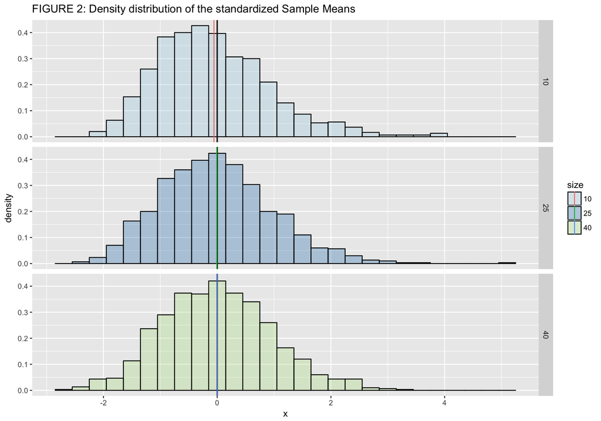

```r
ggplot(dfStandMeans, aes(x = x)) +
     geom_histogram(alpha = .3, binwidth=.3, colour = "black", aes(y = ..density.., fill = size)) +
     scale_fill_brewer(palette = "Paired") +
     ggtitle("FIGURE 2: Density distribution of the standardized Sample Means") +
     geom_vline(xintercept = 0, col = "#242424", size = .8) +
     geom_vline(data = ddply(dfStandMeans, "size", summarize, m = mean(x)), aes(xintercept = m, col = size)) +
     facet_grid(size ~ .)
```

The FIGURE 2 above, shows us how the coloured line (Sample Mean) approaches the grey line (Theoretical Mean) as the number of simulations increases. When the simulation group has n = 40, the Sample Mean seems to be exactly equal to the Theoretical Mean with the naked eye.

As we saw above, the Theoretical Mean is 1/*lambda*, in this case, 1/0.2 = 5. However, to comparison propose, we standardized the mean density distribution. It means the mean is now **0**. The Sample Means are:

```r
mean(dfStandMeans[dfStandMeans$size == 10,]$x)
```

```
## [1] -0.05675612
```

```r
mean(dfStandMeans[dfStandMeans$size == 25,]$x)
```

```
## [1] -0.007648125
```

```r
mean(dfStandMeans[dfStandMeans$size == 40,]$x)
```

```
## [1] -0.0001081411
```

Respectively for n equals to 10, 25 and 40. We can how the Sample Mean is close to 0 for n = 40.

## Sample Variance versus Theoretical Variance

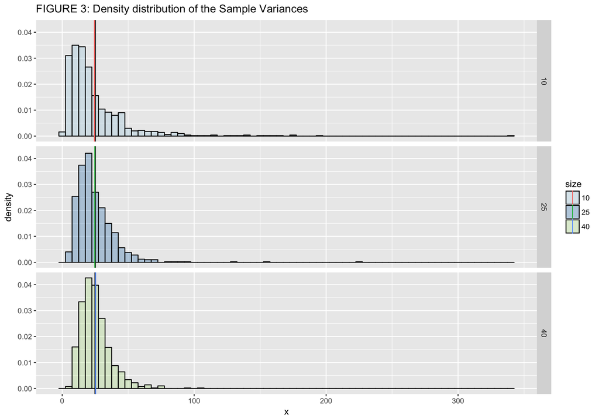

```r
ggplot(dfVariance, aes(x = x)) +
     geom_histogram(alpha = .3, binwidth=5, colour = "black", aes(y = ..density.., fill = size)) +
     scale_fill_brewer(palette = "Paired") +
     ggtitle("FIGURE 3: Density distribution of the Sample Variances") +
     geom_vline(xintercept = var, col = "#242424", size = .8) +
     geom_vline(data = ddply(dfVariance, "size", summarize, m = mean(x)), aes(xintercept = m, col = size)) +
     facet_grid(size ~ .)
```

The FIGURE 3 above, shows us how the coloured line (Sample Variances Mean) approaches the grey line (Theoretical Variances Mean) as the number of simulations increases. When the simulation group has n = 40, the Sample Variances Mean seems to be exactly equal to the Theoretical Variances Mean with the naked eye.

As we saw above, the Theoretical Variance is 1/*lambda*^2, in this case, 1/0.2^2 = **25**. The Sample Means are:

```r
mean(dfVariance[dfVariance$size == 10,]$x)
```

```
## [1] 24.40333
```

```r
mean(dfVariance[dfVariance$size == 25,]$x)
```

```
## [1] 24.70705
```

```r
mean(dfVariance[dfVariance$size == 40,]$x)
```

```
## [1] 25.37078
```

Respectively for n equals to 10, 25 and 40.

## Normal Distribution

The Central Limit Theorem states that the sampling distribution of the sample means approaches a normal distribution as the sample size gets larger — no matter what the shape of the population distribution.

FIGURE 4 shows how the standardized Sample Means density curve (colorful line) approaches to the standard normal (dashed grey line) as the number of samples increases. When n = 40 the blue curve is pretty close to the standard normal.

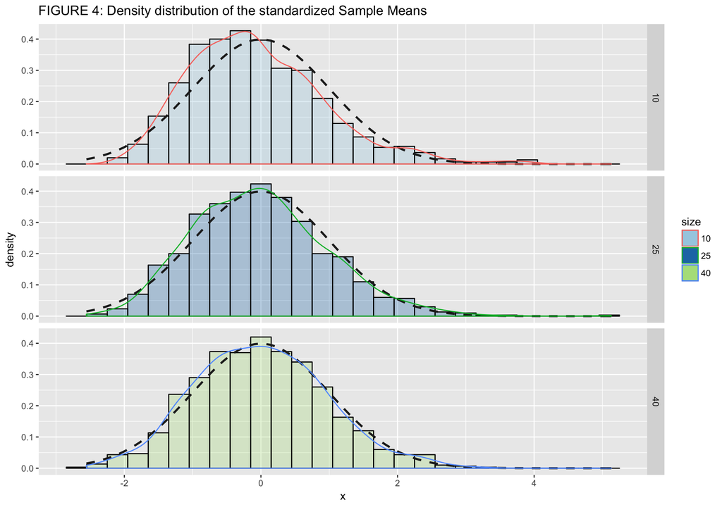

```r
ggplot(dfStandMeans, aes(x = x)) +
     geom_histogram(alpha = .3, binwidth=.3, colour = "black", aes(y = ..density.., fill = size)) +
     scale_fill_brewer(palette = "Paired") +
     ggtitle("FIGURE 4: Density distribution of the standardized Sample Means") +
     stat_function(fun = dnorm, size = 1, colour = "#242424", linetype = "dashed") +
     geom_density(aes(colour = size, fill = NULL)) +
     facet_grid(size ~ .)
```

Another way of visualizing the approximation of the standardized Sample Means distribution with the standard normal distribution is the use of a Q-Q plot. This is exactly what the FIGURE 5 does.

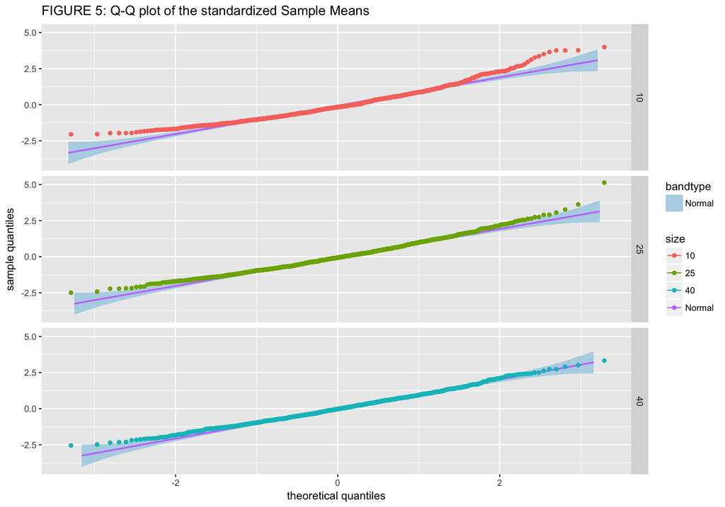

```r
ggplot(dfStandMeans, aes(sample = x)) +
     geom_qq_band(bandType = "normal", mapping = aes(fill = "Normal")) +
     stat_qq_line(mapping = aes(colour = "Normal")) +
     stat_qq(aes(colour = size)) +
     scale_fill_brewer(palette = "Paired") +
     ggtitle("FIGURE 5: Q-Q plot of the standardized Sample Means") +
     labs(x = "theoretical quantiles", y = "sample quantiles", color = "size", fill = "bandtype") +
     facet_grid(size ~ .)
```

Again we can see how close the distribution with n = 40 is to the standard normal.